# Time Series Practice

#### How it works…

- Step 1 reads the data and Step 2 creates and plots the time series. For more details, see the recipe, Using time series objects, earlier in this chapter.
- Step 3 shows the use of the stl function to decompose an additive time series. Since our earlier plot indicated that the amplitude of the fluctuations increased with time, thereby suggesting a multiplicative time series, we applied the log function to convert it into an additive time series and then decomposed it.
- Step 4 uses the plot function to plot the results.
- Step 5 uses the decompose function to perform a decomposition through moving averages and then plots it.
- Step 6 adjusts gas prices for seasonality by subtracting the seasonal component from the original time series of the gas prices, and then plots the resulting time series.

### Filtering time series data

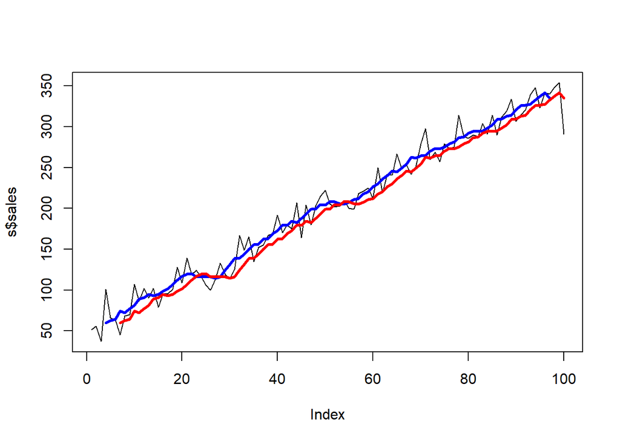

```r
#To filter time series data, follow these steps:
#1. Read the data. The file has fictitious weekly sales data for some product:
 s <- read.csv("ts-example.csv")
#2. Create the filtering vector. We assume a seven-period filter:
 n <- 7
 wts <- rep(1/n, n)
#3. Compute the symmetrically filtered values (three past values, one current value, and three future values) and one-sided values (one current and six past values:
 s.filter1 <- filter(s$sales, filter = wts, sides = 2)
 s.filter2 <- filter(s$sales, filter = wts, sides = 1)
#4. Plot the filtered values:
 plot(s$sales, type = "l")
 lines(s.filter1, col = "blue", lwd = 3)
 lines(s.filter2, col = "red", lwd = 3)
```

#### How it works…

- Step 1 reads the data.
- Step 2 creates the filtering weights. We used a window of seven periods. This means that the weighted average of the current value and six others will comprise the filtered value at the current position.
- Step 3 computes the two-sided filter (the weighted average of the current value and three prior and three succeeding values) and a one-sided filter based on the current value and six prior ones.
- Step 4 plots the original data and the symmetric and one-sided filters. We can see that the two-sided filter tracks the changes earlier.

#### Smoothing and forecasting using the Holt-Winters method

```r
#To apply the HoltWinters method for exponential smoothing and forecasting, follow these steps:
#1. Read the data. The file has monthly stock prices from Yahoo! Finance for Infosys between March 1999 and January 2015:
 infy <- read.csv("infy-monthly.csv")
#2. Create the time series object:
 infy.ts <- ts(infy$Adj.Close, start = c(1999,3), frequency = 12)
#3. Perform Holt-Winters exponential smoothing:
 infy.hw <- HoltWinters(infy.ts)
#4. Plot the results:
 plot(infy.hw, col = "blue", col.predicted = "red")

# Examine the results:
 # See the squared errors
 infy.hw$SSE
```

```
## [1] 1446.232
```

```r
 # The alpha beta and gamma used for filtering
 infy.hw$alpha
```

```
##     alpha
## 0.5658932
```

```r
 infy.hw$beta
```

```
##        beta
## 0.009999868
```

```r
 infy.hw$gamma
```

```
## gamma
##     1
```

```r
 # the fitted values
 head(infy.hw$fitted)
```

```
##          xhat    level     trend      season
## [1,] 13.91267 11.00710 0.5904618  2.31510417
## [2,] 18.56803 15.11025 0.6255882  2.83218750
## [3,] 15.17744 17.20828 0.6403124 -2.67114583
## [4,] 19.01611 18.31973 0.6450237  0.05135417
## [5,] 15.23710 18.66703 0.6420466 -4.07197917
## [6,] 18.45236 18.53545 0.6343104 -0.71739583
```

[figure not shown]

```r
# Generate and plot forecasts with the Holt-Winters model:
 library(forecast)
```

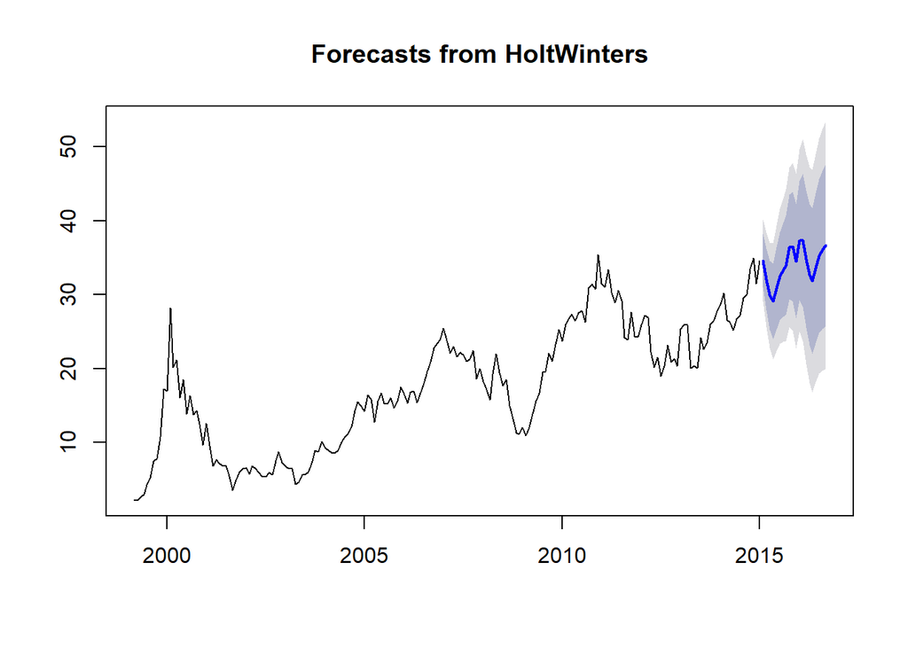

```r
 infy.forecast <- forecast(infy.hw, h=20)
 plot(infy.forecast)
```

How it works…

### Building an automated ARIMA model

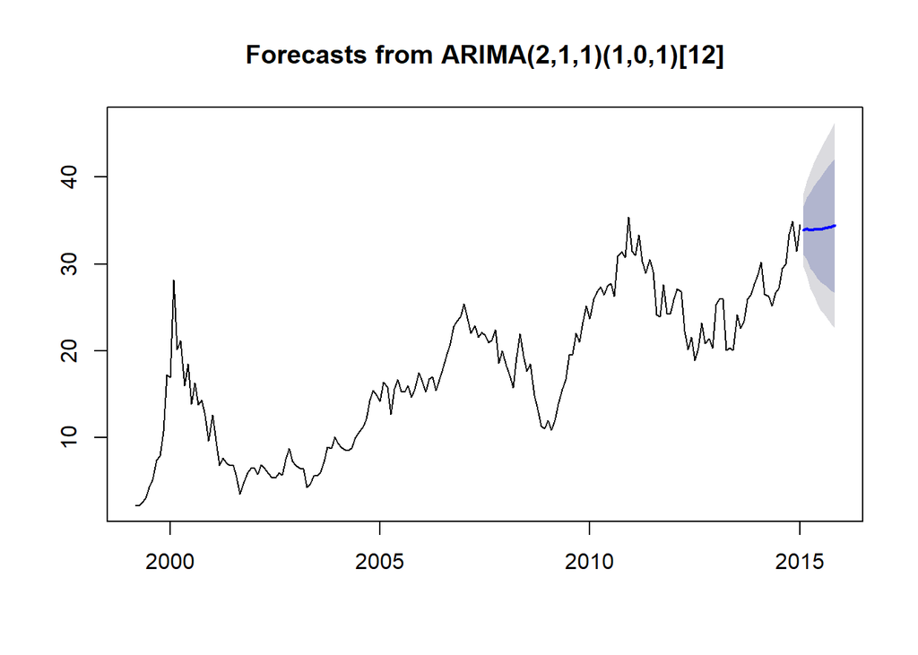

```r
#To build an automated ARIMA model, follow these steps:
#1. Read the data. The file has monthly stock prices from Yahoo! Finance for Infosys between March 1999 and January 2015:
 infy <- read.csv("infy-monthly.csv")
#2. Create the time series object:
 infy.ts <- ts(infy$Adj.Close, start = c(1999,3), frequency = 12)
#3. Run the ARIMA model:
 infy.arima <- auto.arima(infy.ts)
#4. Generate the forecast using the ARIMA model:
 infy.forecast <- forecast(infy.arima, h=10)
#5. Plot the results:
 plot(infy.forecast)
```

How it works…